# sharadkanoongo_ML_3

```python
import pandas as pd
import numpy as np
import seaborn as sns
from scipy import stats
import matplotlib.pyplot as plt
%matplotlib inline
from sklearn.preprocessing import StandardScaler
from sklearn.cluster import KMeans
import sklearn.cluster as cl
```

```python
df = pd.read_csv('C:\\Users\\user\\Desktop\\DS\\assinment\\ML\\ML - Assignment 3\\driver_data.csv')
df.head()
```

|  | Distance_Feature | Speeding_Feature |
| --- | --- | --- |
| 0 | 71.24 | 28 |
| 1 | 52.53 | 25 |
| 2 | 64.54 | 27 |
| 3 | 55.69 | 22 |
| 4 | 54.58 | 25 |

```python
df.shape
```

```
(4000, 2)
```

```python
df.describe()
```

|  | Distance_Feature | Speeding_Feature |
| --- | --- | --- |
| count | 4000.000000 | 4000.000000 |
| mean | 76.041523 | 10.721000 |
| std | 53.469563 | 13.708543 |
| min | 15.520000 | 0.000000 |
| 25% | 45.247500 | 4.000000 |
| 50% | 53.330000 | 6.000000 |
| 75% | 65.632500 | 9.000000 |
| max | 244.790000 | 100.000000 |

```python
df.info()
```

```
<class 'pandas.core.frame.DataFrame'>
RangeIndex: 4000 entries, 0 to 3999
Data columns (total 2 columns):
 #   Column            Non-Null Count  Dtype
---  ------            --------------  -----
 0   Distance_Feature  4000 non-null   float64
 1   Speeding_Feature  4000 non-null   int64
dtypes: float64(1), int64(1)
memory usage: 62.6 KB
```

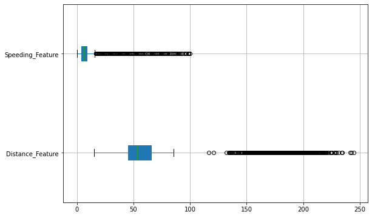

```python
plt.figure(figsize=(9,6))
df.boxplot(patch_artist=True,vert=False)
```

```
(0.0, 256.2535)
```

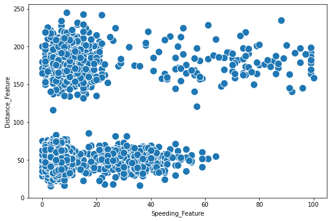

```python
plt.figure(figsize=(9,6))
sns.scatterplot(x="Speeding_Feature", y="Distance_Feature", data = df, markers='o', edgecolors='black', s=150)
plt.ylim(0,)
```

The Below shown Jointplot is a Plot between Speeding_Feature and Distace_Feature From the plot we can see that datapoints in Both the features are Right Skewed and regression plot shows a Positive Slope i.e. Speeding_Feature(Time > 5 MPH Overspeeding) increases the distance increases which is obvious

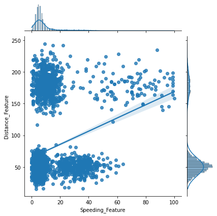

```python
sns.jointplot(x="Speeding_Feature", y="Distance_Feature", data=df, kind="reg");
```

```python
from sklearn.preprocessing import StandardScaler
```

```python
std_scale = StandardScaler().fit(df)
```

```python
df_scaled = std_scale.transform(df)
```

```python
df_scaled[:5,]
```

```
array([[-0.0898104 ,  1.26061251],
       [-0.43977285,  1.04174351],
       [-0.215131  ,  1.18765617],
       [-0.38066642,  0.8228745 ],
       [-0.40142849,  1.04174351]])
```

Running multiple iteration of KMeans algorithm to find an optimal number of clusters using elbow method and also using Silhoutte Score.

```python
from sklearn.cluster import KMeans
import sklearn.cluster as cl
```

```python
ssq = []
for K in range(1,9):
    kmeans_model = KMeans(n_clusters=K, random_state=123)
    kmeans_model.fit(df_scaled)
    ssq.append(kmeans_model.inertia_)
```

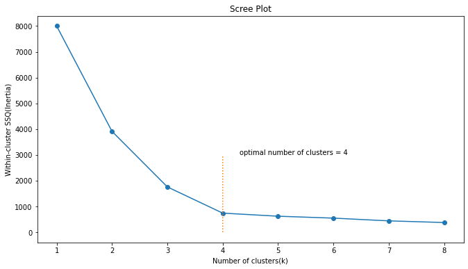

```python
plt.figure(figsize=(11,6))
plt.plot(range(1,9), ssq, marker='o')
plt.xlabel("Number of clusters(k)")
plt.ylabel("Within-cluster SSQ(Inertia)")
plt.title("Scree Plot")
plt.plot([4]*3000, range(1,3001), ":")
plt.text(4.3, 3000, "optimal number of clusters = 4")
plt.show()
```

From the result we see that Four should be the optimal number of clusters for the given data as After 4th Cluster the change in number of Clusters won't give that effective result.

So Let's consider No. of Clusters = 4

K-Means Clustering

```python
km = KMeans(n_clusters=4, random_state=123)
km.fit(df_scaled)
```

```
KMeans(n_clusters=4, random_state=123)
```

Make predictions for the clusters of the given dataset

```python
predicted_cluster = km.predict(df_scaled)
```

```python
predicted_cluster[:13]
```

```
array([3, 3, 3, 3, 3, 0, 3, 0, 3, 3, 3, 3, 3])
```

Checking and Determining the No. of Clusters taken by using Silhoutte Score

```python
import sklearn.metrics as metrics
labels=cl.KMeans(n_clusters=7,random_state=200).fit(df_scaled).labels_
```

```python
metrics.silhouette_score(df_scaled,labels,metric="euclidean",sample_size=4000,random_state=200)
```

```
0.6672608445690347
```

```python
for i in range(2,11):
    labels=cl.KMeans(n_clusters=i,random_state=123).fit(df_scaled).labels_
    print ("Silhoutte score for k= "+str(i)+" is "+str(metrics.silhouette_score(df_scaled,labels)))
```

```
Silhoutte score for k= 2 is 0.7075955632562002
Silhoutte score for k= 3 is 0.7636008195603978
Silhoutte score for k= 4 is 0.7843727073779272
Silhoutte score for k= 5 is 0.7341393562942123
Silhoutte score for k= 6 is 0.6695347780615145
Silhoutte score for k= 7 is 0.4264647567009382
Silhoutte score for k= 8 is 0.3581785007071867
Silhoutte score for k= 9 is 0.3604911877643239
Silhoutte score for k= 10 is 0.35293722305799463
```

From the above Silhoutte Score we can see that Selecting K=4 using elbow method is correct decision. So K=4 gives better score.

```python
print(km.cluster_centers_)
```

```
[[-0.48678423 -0.40249736]
 [ 1.90400473  4.34582367]
 [ 1.95263225 -0.0139714 ]
 [-0.47952334  1.57909169]]
```

Importing Silhouette Score

```python
from sklearn.metrics import silhouette_score
```

```python
silhouette_score(df_scaled,predicted_cluster)
```

```
0.7843727073779272
```

The above silhouette Score represents that 78.4% of the data within its own cluster (cohesion) are similar as compared to other clusters (separation).

Hierarchical Clustering

Dataset of delivery fleet driver data. For each driver we have two features: mean distance driven per day and the mean percentage of time a driver was >5 mph over the speed limit. Objective: Perform Agglomerative clustering on the fleet driver data dataset with an appropriate number of clusters. Plot the dendrogram and Compare the results from your K-Means model and your Hierarchical clustering model using silhouette scores.

```python
from scipy.cluster.hierarchy import linkage, dendrogram
import matplotlib.pyplot as plt
%matplotlib inline
```

```python
z = linkage(df_scaled, method='ward', metric='euclidean')
```

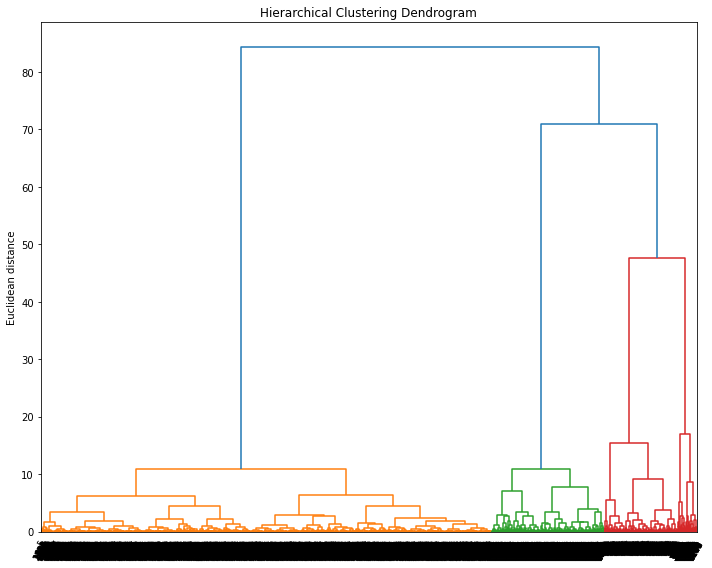

```python
fig,ax = plt.subplots(figsize=(10,8))
plt.title('Hierarchical Clustering Dendrogram')
plt.ylabel("Euclidean distance")
dendrogram(z,labels=df.index,leaf_rotation=60,leaf_font_size=8)
plt.tight_layout()
plt.show()
```

The above shown plot describes Hierarchical Clustering Dendrograms> This is a Bottom-Up Approach and we select the number of clusters by looking at Height of each clades. The more the height of clades(Vertical) we select that many clusters

```python
from sklearn.cluster import AgglomerativeClustering
```

```python
model = AgglomerativeClustering(n_clusters=4)
```

```python
model.fit(df_scaled)
```

```
AgglomerativeClustering(n_clusters=4)
```

```python
model.labels_
```

```
array([1, 1, 1, ..., 2, 2, 2], dtype=int64)
```

Silhouette_score for Agglomerative Clustering

```python
silhouette_score(df_scaled, model.labels_)
```

```
0.778897040913367
```

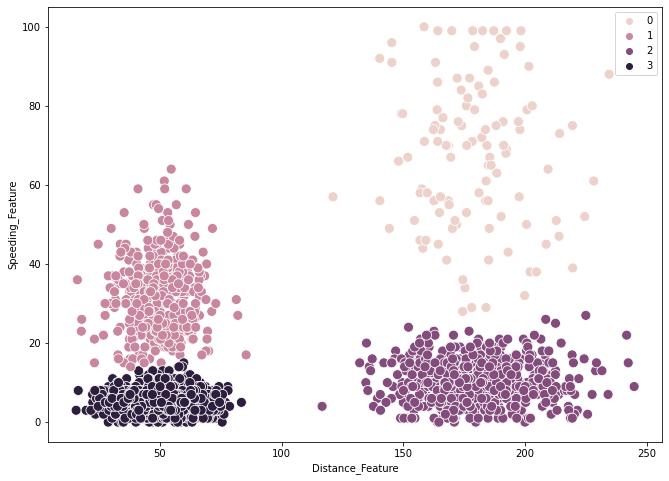

```python
plt.figure(figsize=(11, 8))
sns.scatterplot(x='Distance_Feature', y='Speeding_Feature', data= df, hue=model.labels_, s=100)
plt.show()
```

objective

Silhouette Score of K-Means: 0.7843727073779272

Silhouette Score of Hierarchical Clustering: 0.778897040913367